# CitiBike Report

Evan Colony, Jake Gandolfo, Lisa Duong, Safwaan Mir, Youssef Afify

12/10/19

Packages that we will use throughout the Rmd

```r
library(dplyr, warn.conflicts=FALSE, quietly=TRUE)
library(ggplot2, warn.conflicts=FALSE, quietly=TRUE)
library(leaflet, warn.conflicts=FALSE, quietly=TRUE)
library(lubridate, warn.conflicts=FALSE, quietly=TRUE)
library(kableExtra, warn.conflicts=FALSE, quietly=TRUE)
library(geosphere, warn.conflicts=FALSE, quietly=TRUE)
```

First, all this data was seperated by month into multiple CSVs, which we had to condense into one fullData file. After this, because there was so much data we had to take a sample. The code for these operatins is shown (but not evaluated) below:

```r
dataLocations <- list.files("C:/randomFiles/TOClasses/TO404/citiBike", full.names = TRUE)
# This list has more than what we want, so we need to remove all the values that are not the monthly CSVs
dataLocations <- dataLocations[-13:-18]

data1 <- read.csv("201801-citibike-tripdata.csv")
data2 <- read.csv("201802-citibike-tripdata.csv")
data3 <- read.csv("201803-citibike-tripdata.csv")
data4 <- read.csv("201804-citibike-tripdata.csv")
data5 <- read.csv("201805-citibike-tripdata.csv")
data6 <- read.csv("201806-citibike-tripdata.csv")
data7 <- read.csv("201807-citibike-tripdata.csv")
data8 <- read.csv("201808-citibike-tripdata.csv")
data9 <- read.csv("201809-citibike-tripdata.csv")
data10 <- read.csv("201810-citibike-tripdata.csv")
data11 <- read.csv("201811-citibike-tripdata.csv")
data12 <- read.csv("201812-citibike-tripdata.csv")

fullData <- bind_rows(data1, data2, data3, data4, data5, data6, data7)
fullData$start.station.id <- as.factor(fullData$start.station.id)
fullData$end.station.id <- as.factor(fullData$end.station.id)
fullData <- bind_rows(fullData, data8, data9, data10, data11, data12)
# Write the csv for future use
write.csv(fullData, "fullData.csv")
```

Before we move on to get our random sample, we first checked for any data that should be kept as a factor. We decided that gender, userType, bikeid, and the stationids as factors

```r
fullData$gender <- as.factor(fullData$gender)
fullData$usertype <- as.factor(fullData$usertype)
fullData$bikeid <- as.factor(fullData$bikeid)
fullData$end.station.id <- as.factor(fullData$end.station.id)
fullData$start.station.id <- as.factor(fullData$start.station.id)
```

Now, we take a random sample and write it to a CSV to ensure all members test on the same data.

```r
testData <- sample_frac(full, .01)
write.csv(testData, "testData.csv")
```

The below code is for simplicity of work for now

```r
test <- read.csv("fullData.csv")
test$bikeid <- as.factor(test$bikeid)
test$gender <- as.factor(test$gender)
test$starttime <- as.character(test$starttime)
test$stoptime <- as.character(test$stoptime)
test$X <- NULL

# Removes the Canada Stations
test <- test %>%
  filter(start.station.latitude < 43)

test <- test %>%
  mutate(pastTime = hour(starttime) *60 + minute(starttime) + second(starttime)/60)
```

With the test data now extracted, we then need to understand the data.

# Question 1: Understand the data

Download all the monthly data and combine to create a 2018 year dataset. Explore the dataset to calculate descriptive statistics. Do exploratory visualization to better understand the dataset.

## Data Cleaning

### Fixing trip duration errors

```r
# Here, we are adding a column that shows the tri duration in minutes instead of seconds, which is easier for us to understand
test$tripDurationMin <- test$tripduration/(60)
#Looking at a brief overview of how long trips take.
summary(test$tripDurationMin)
```

```
##     Min.  1st Qu.   Median     Mean  3rd Qu.     Max.
##      1.0      6.0     10.1     16.5     17.7 325167.5
```

[output not shown]

### Changing Gender Integers to Strings

```r
# First, we assign the name of the gender to each numebr
levels(test$gender) <- c("Unkown", "Male", "Female")
summary(test$gender)
```

```
##   Unkown     Male   Female
##  1484553 11971246  4092459
```

```
Here we see that there are significanlty more uses by males than any other gender. We also see a lot of use by the Unknown gender type, which means that no data was collected on the gender of these users.
```

```r
#Adding a column to the dataframe for generation. This would help in marketing should the company want to target specific customers and to analyze differences by differnt generations
test$generation <- ifelse(test$birth.year >= 1934 & test$birth.year < 1946, "Silent Gen", ifelse(test$birth.year >= 1946 & test$birth.year <= 1964, "Baby Boomer",ifelse(test$birth.year >= 1965 & test$birth.year <= 1979, "Gen X", ifelse(test$birth.year >= 1980 & test$birth.year <= 1994, "Millennials", ifelse(test$birth.year >= 1995, "Gen Z", NA)))))
test$generation <- as.factor(test$generation)
```

### Adding and Analysing Age

```r
# We also use birth year to calculate age to make some analyses more descriptive
test$age <- 2019 - test$birth.year

summary(test$age)
```

```
##    Min. 1st Qu.  Median    Mean 3rd Qu.    Max.
##   17.00   30.00   38.00   40.01   50.00  134.00
```

[output not shown]

```r
# Requires: X is the checking value, Y is the value ot be changed based on the check
# Effects: Sets the value of Y to NA if X meets a certian condition
fixAge <- function(x) {
  if (x > 85) {
    NA
  } else {
    x
  }
}


fixYear <- function(x) {
  if (x < 2019 - 85) {
    NA
  } else {
    x
  }
}

# Replaces invalid ages with NA
test$birth.year <- sapply(test$birth.year, FUN=fixYear)
test$age <- sapply(test$age, FUN=fixAge)
summary(test$age)
```

```
##    Min. 1st Qu.  Median    Mean 3rd Qu.    Max.    NA's
##   17.00   30.00   38.00   39.94   50.00   85.00   15469
```

```r
summary(test$birth.year)
```

```
##    Min. 1st Qu.  Median    Mean 3rd Qu.    Max.    NA's
##    1934    1969    1981    1979    1989    2002   15469
```

## Descriptive Statistics

### Age

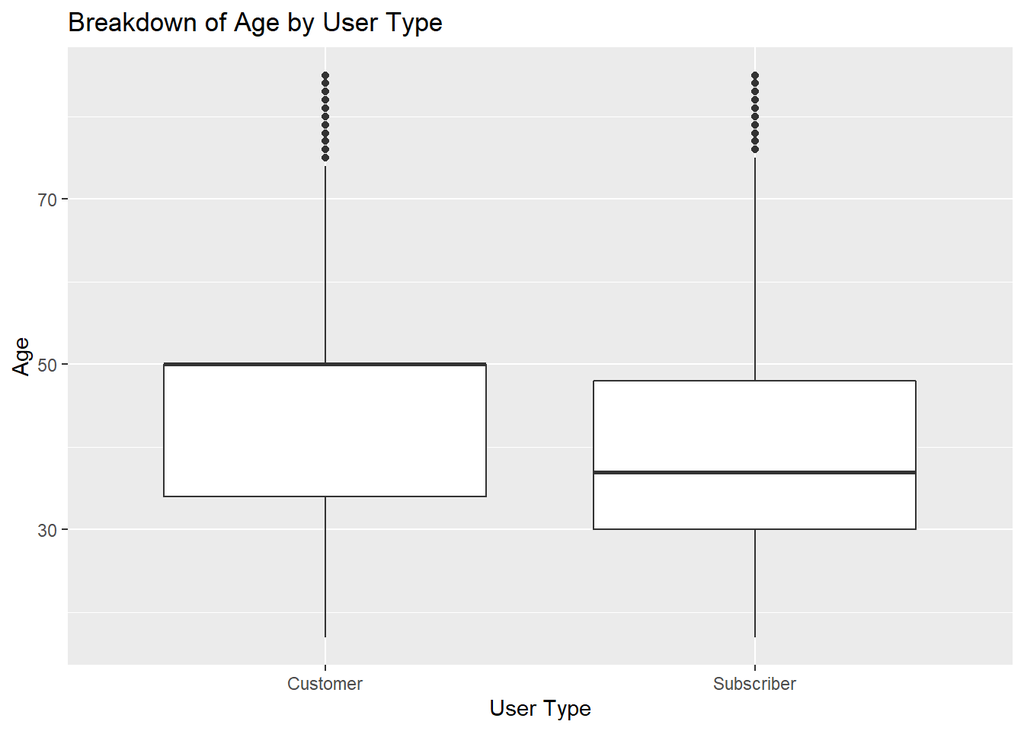

[output not shown]

```r
ggplot(test, aes(x=usertype, y=age)) + geom_boxplot() + labs(x = "User Type", y = "Age", title = "Breakdown of Age by User Type")
```

### Origin Duration

```
Next, we wanted to break down trip duration by station. Each station is in a different location around New York City, and we wanted to see the average trip duration by station to see if some stations take longer to get to.
```

```r
#Most popular Start stations
startstation=group_by(test,start.station.name)%>%
  summarise(
    count=n()
  )%>%
arrange(desc(count))
print(startstation)
```

```
## # A tibble: 820 x 2
##    start.station.name     count
##    <fct>                  <int>
##  1 Pershing Square North 150257
##  2 E 17 St & Broadway    108883
##  3 W 21 St & 6 Ave       107165
##  4 Broadway & E 22 St    105605
##  5 West St & Chambers St  94466
##  6 Broadway & E 14 St     93370
##  7 W 41 St & 8 Ave        87956
##  8 8 Ave & W 33 St        85293
##  9 Broadway & W 60 St     84963
## 10 Lafayette St & E 8 St  83025
## # ... with 810 more rows
```

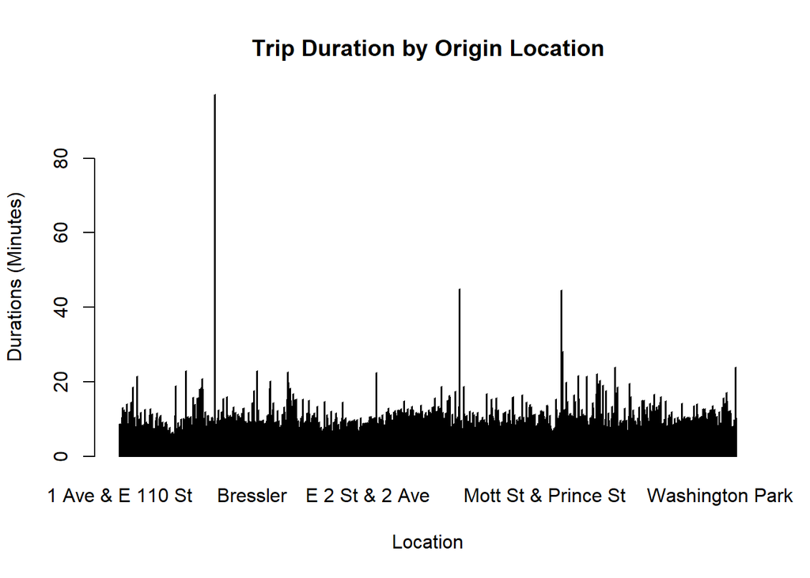

```
We see that most trips look fairly simialr, however, there are some large outliers.
```

[output not shown]

```r
# This gets the average trip duration from each start station
duration_minutes_start <- tapply(test$tripDurationMin, test$start.station.name, median)

barplot(duration_minutes_start, main = "Trip Duration by Origin Location", ylab = "Durations (Minutes)", xlab= "Location")
```

### Destination Duration

```r
#most popular End stations
endstation=group_by(test, end.station.name)%>%
  summarise(
    count=n()
  )%>%
arrange(desc(count))
print(endstation)
```

```
## # A tibble: 853 x 2
##    end.station.name       count
##    <fct>                  <int>
##  1 Pershing Square North 149932
##  2 E 17 St & Broadway    113336
##  3 Broadway & E 22 St    109147
##  4 W 21 St & 6 Ave       108636
##  5 West St & Chambers St  99423
##  6 Broadway & E 14 St     93590
##  7 W 41 St & 8 Ave        88141
##  8 8 Ave & W 33 St        85290
##  9 12 Ave & W 40 St       85143
## 10 Lafayette St & E 8 St  84123
## # ... with 843 more rows
```

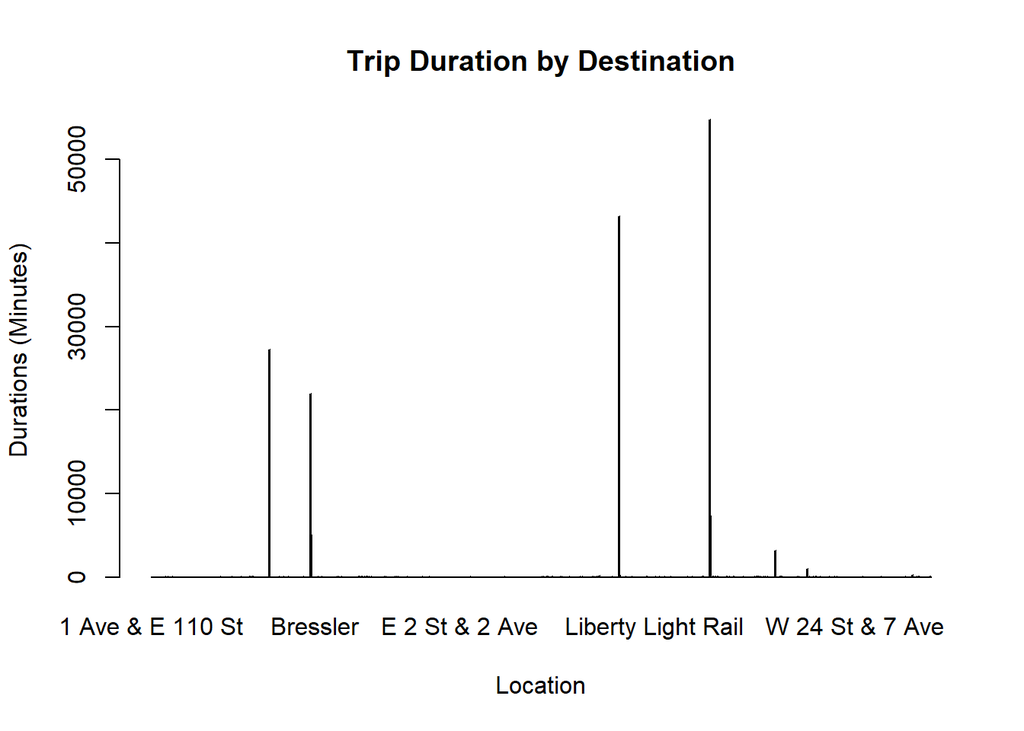

```
In this graph we see much higher outlier values for durations.
```

[output not shown]

[output not shown]

```r
#We are also curious to see if any destination stations have significantly high median trip durations.
duration_by_end <- tapply(test$tripDurationMin, test$end.station.name, median)
barplot(duration_by_end, main = "Trip Duration by Destination", ylab = "Durations (Minutes)", xlab= "Location")
```

### User Type

```r
summary(test$usertype)
```

```
##   Customer Subscriber
##    1933505   15614753
```

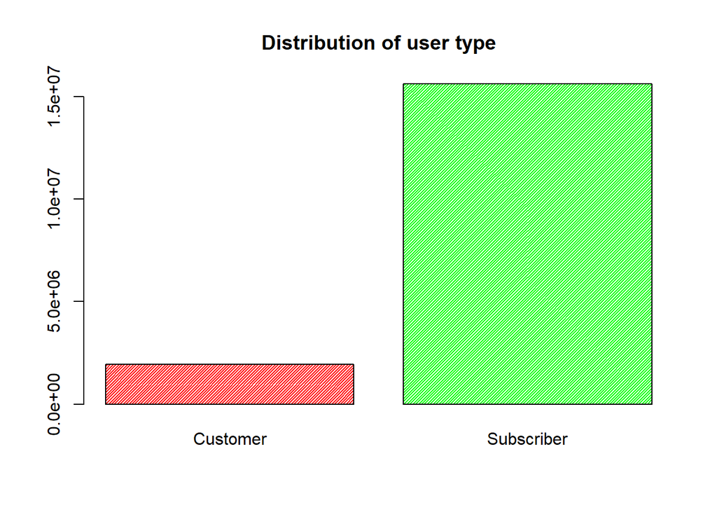

```
There are significantly more subscribers than Customers. It is unlikely that a difference this large is due to viewing a subset of the overall data. It does make sense that there are more subscribers, since they pay for the service and what to get their money's worth.
```

```r
barplot(table(test$usertype), main = "Distribution of user type", col = rainbow(3), density = 50)
```

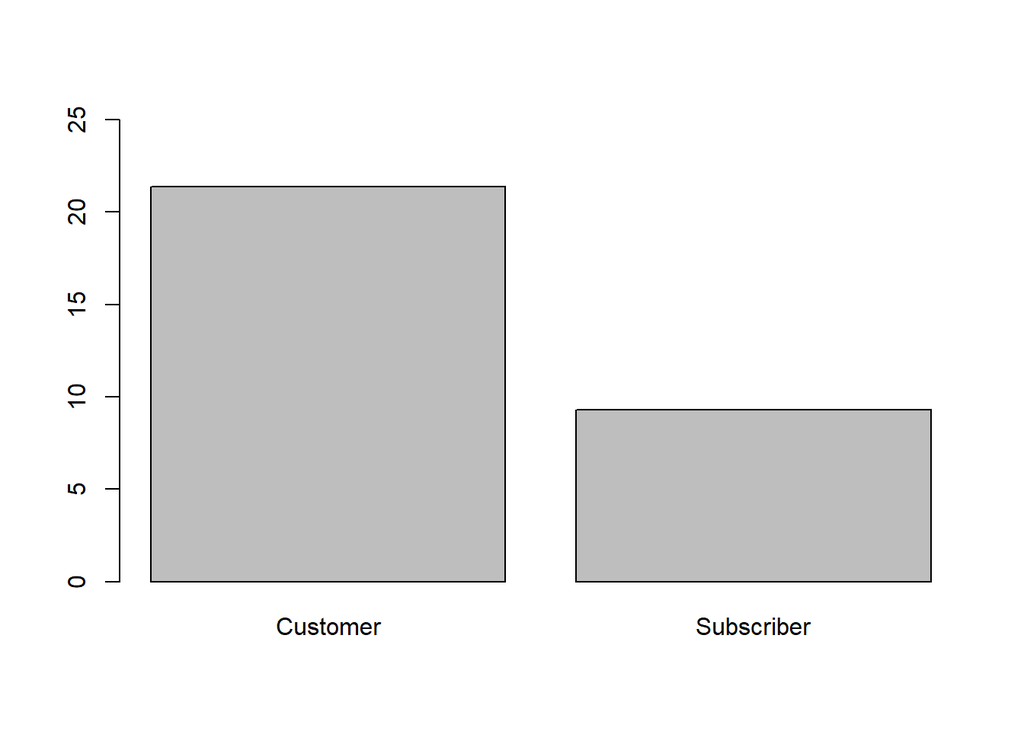

```
This data and the accompanying bar graph show that customers spend signifincantly more time on the bikes than subscribers do.
```

```r
barplot(tapply(test$tripDurationMin, test$usertype, median, na.rm = TRUE), ylim=c(0,25))
```

### Gender

```
We wanted to see if there is a difference between the gender of people who ride Citibike: could this account for the customer subscriber difference?
```

```r
table(test$gender)
```

```
##
##   Unkown     Male   Female
##  1484553 11971246  4092459
```

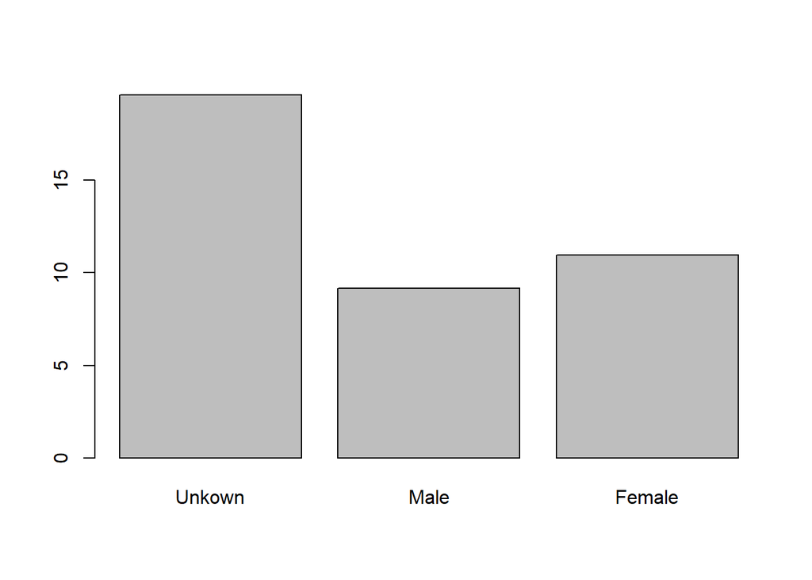

```
Can the difference in male and female users be explained by Usertype?
```

```r
#Now, we would like to see if there is a difference in trip duration by gender.
barplot(tapply(test$tripDurationMin, test$gender, median))
```

```r
table((test %>% filter(usertype=="Customer"))$gender)
```

```
##
##  Unkown    Male  Female
## 1179469  474225  279811
```

```r
table((test %>% filter(usertype=="Subscriber"))$gender)
```

```
##
##   Unkown     Male   Female
##   305084 11497021  3812648
```

```
The large difference in males to females is because most of Citibikes subscribers are males. Citibike may want to make a push towards getting more women subscribers as a means of possible revenue growth.
```

### Generation

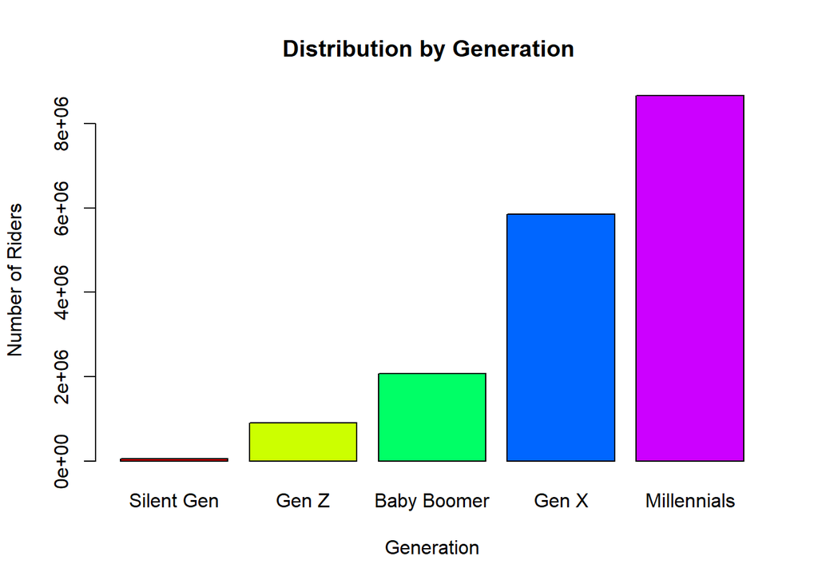

```
Most of the Citibike's users are Millenials and GenX, who are likely to be in the labor force.This makes sense because most users are also subscribers, meaning they should have sustainable income to afford the fee.
```

```r
barplot(sort(table(test$generation)), main = "Distribution by Generation ", col = rainbow(5), xlab = "Generation", ylab = "Number of Riders")
```

### Distance and Speed Data

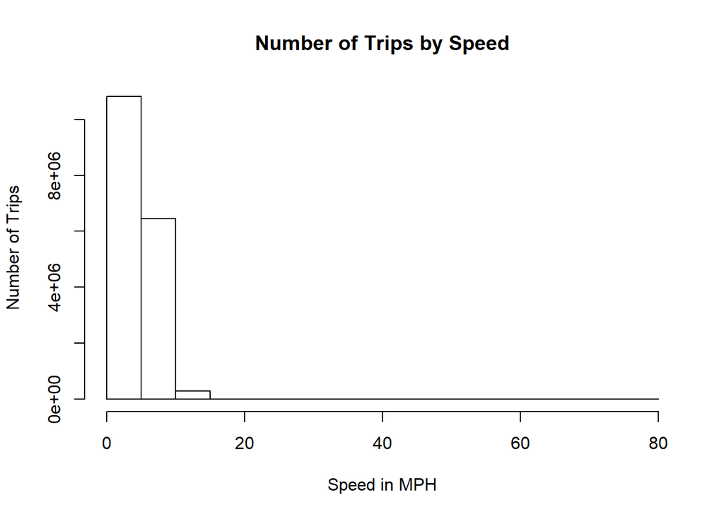

```
Here we see that the speed follows a right skewed distribution, the meadian is below the mean. The meadian speed of this data is 4.1213084.
```

```r
# Distance Travelled and speed
calc_station_dist <- function(test){
          start <- cbind(as.numeric(test$start.station.latitude), as.numeric(test$start.station.longitude))
          end <- cbind(as.numeric(test$end.station.latitude), as.numeric(test$end.station.longitude))
    distHaversine(start,end)
}
test$dist= calc_station_dist(test)
# Distance calculated in meters
test$speed= (test$dist/test$tripDurationMin)
#Speed found in Meters per minute
test$mph= (test$speed*0.0372823)
#Converting to mph
#Here I am trying to get mean speed by bikeid, can do same by gender or customer type etc, but meanspeed by bikeid and maybe by route is useful
hist(test$mph, main="Number of Trips by Speed", xlab= "Speed in MPH", ylab="Number of Trips",)
```

### Bike ID

```
As a company we want to analyze which of our bikes have the most usage, we can sort our bikes with the longest time checked out and the farthest haversine distance travelled
```

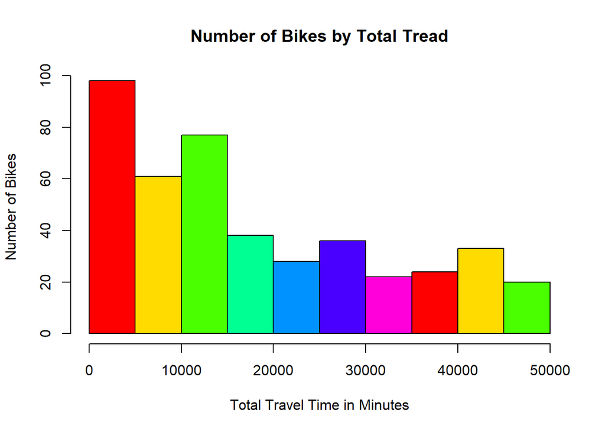

```
Here see that, as total travel time increases, the number of bikes that have traveled that long generally tend to decrease.
```

```r
bikeiddata <- test%>%
  group_by(bikeid) %>%
  summarise(bikecount = n(), meantime = mean(tripduration, na.rm = TRUE), meandist= mean(dist), mph= mean(mph), age= mean(age)) %>%
  mutate(totaltriptime = meantime*bikecount)  %>%
  mutate(totaltripdist = meandist*bikecount)
bikeiddata <- bikeiddata[order(bikeiddata$totaltriptime),]
bikeiddatax <- bikeiddata[-which(bikeiddata$totaltriptime>50000),]
hist(bikeiddatax$totaltriptime, main="Number of Bikes by Total Tread", xlab= "Total Travel Time in Minutes", ylab="Number of Bikes", col = rainbow(7))
```

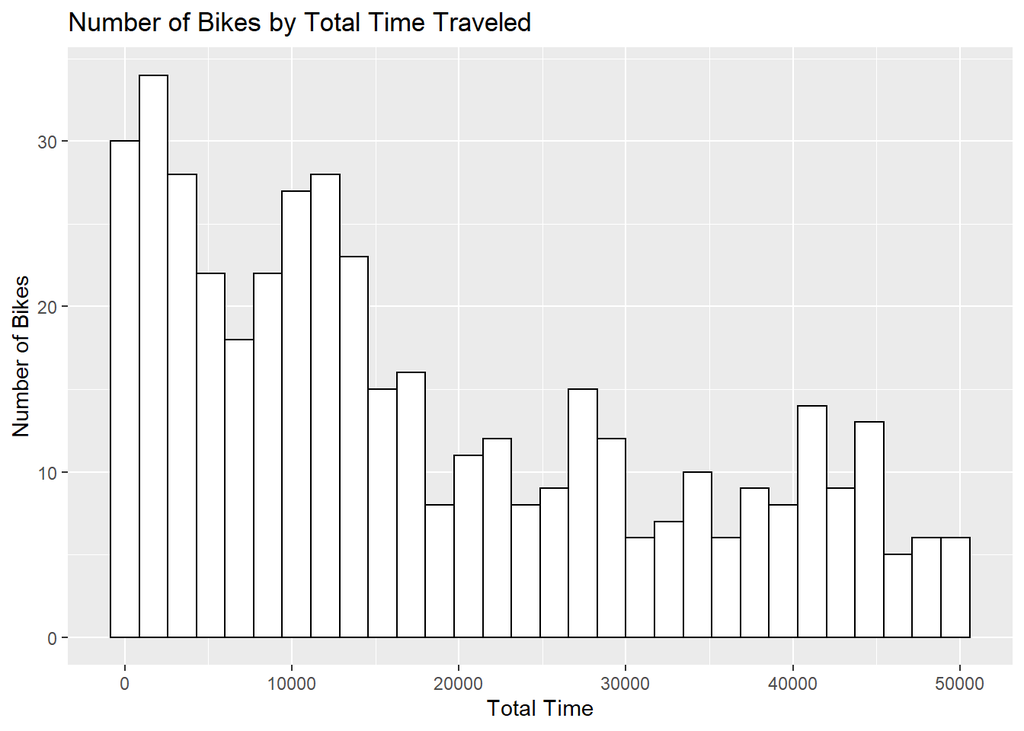

```
Here we see a similar distribution to that of speed. Some bikes are used a lot, which skews the graph to the right, but overall, there is less usage than the mean would suggest, with the median at 1.0646685\times 10^{6}.
```

```r
ggplot(data=bikeiddatax, aes(x=totaltriptime)) + geom_histogram(color="black", fill="white") + geom_density( fill="#FF6666")  + ggtitle("Number of Bikes by Total Time Traveled") +
  xlab("Total Time") + ylab("Number of Bikes")
```

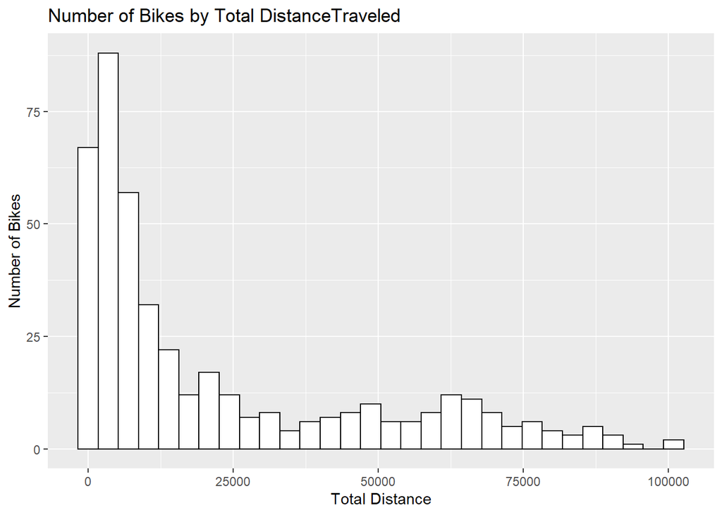

```
Seems like there are more bikes that are far above the mean of bikes for totaltriptime then totaltripdist, even with extreme totaltriptime outliers removed. Lets look further to see how each bike looks comparing the total distance traveled and the total trip time
```

```r
ggplot(data=bikeiddatax, aes(x=totaltripdist)) + geom_histogram(color="black", fill="white") + geom_density( fill="#FF6666") +  ggtitle("Number of Bikes by Total DistanceTraveled") +
  xlab("Total Distance") + ylab("Number of Bikes")
```

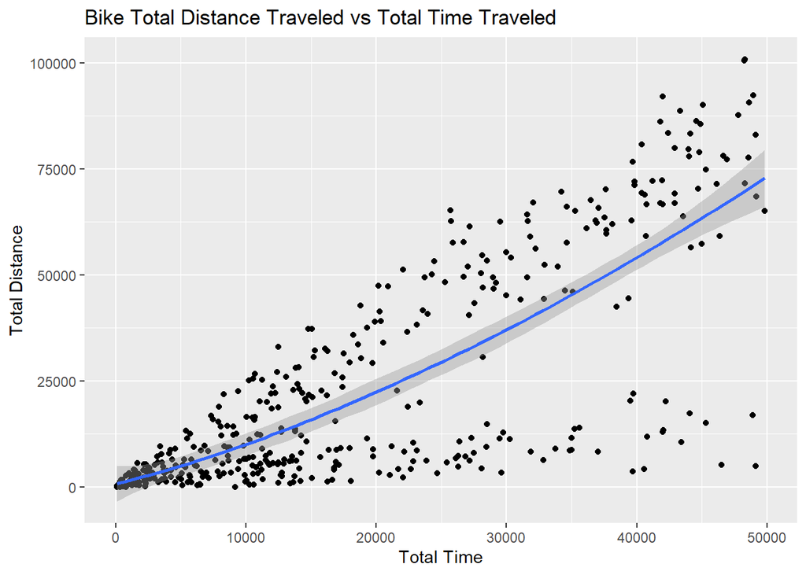

```r
baseplot <- ggplot(data=bikeiddatax, aes(x=totaltriptime, y=totaltripdist))
baseplot + geom_point() + geom_smooth() + ggtitle("Bike Total Distance Traveled vs Total Time Traveled") +
  xlab("Total Time") + ylab("Total Distance")
```

```r
test1 <- bikeiddata %>%
  arrange(desc(totaltripdist)) %>%
  slice(1:10) %>%
  select(bikeid)
```

```
These are the top ten bikes that were used for each metric:
Bikecount: 16600, 17360, 14950, 28171, 35134, 35028, 16564, 18667, 35072, 20018
Trip Distance: 30657, 32124, 32541, 32036, 32090, 31108, 32292, 32115, 30632, 30315
```

```
Now lets analyze what the average speed of a bike is and which bikes are the fastest
```

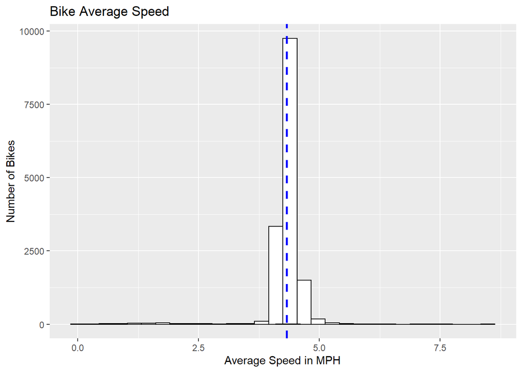

```r
baseplot <- ggplot(data=bikeiddata, aes(x=mph))
baseplot + geom_histogram( colour="black", fill="white") + geom_density(alpha=.2, fill="#FF6666") + ggtitle("Bike Average Speed") + xlab("Average Speed in MPH") + ylab("Number of Bikes") + geom_vline(aes(xintercept=mean(mph)),
color="blue", linetype="dashed", size=1)
```

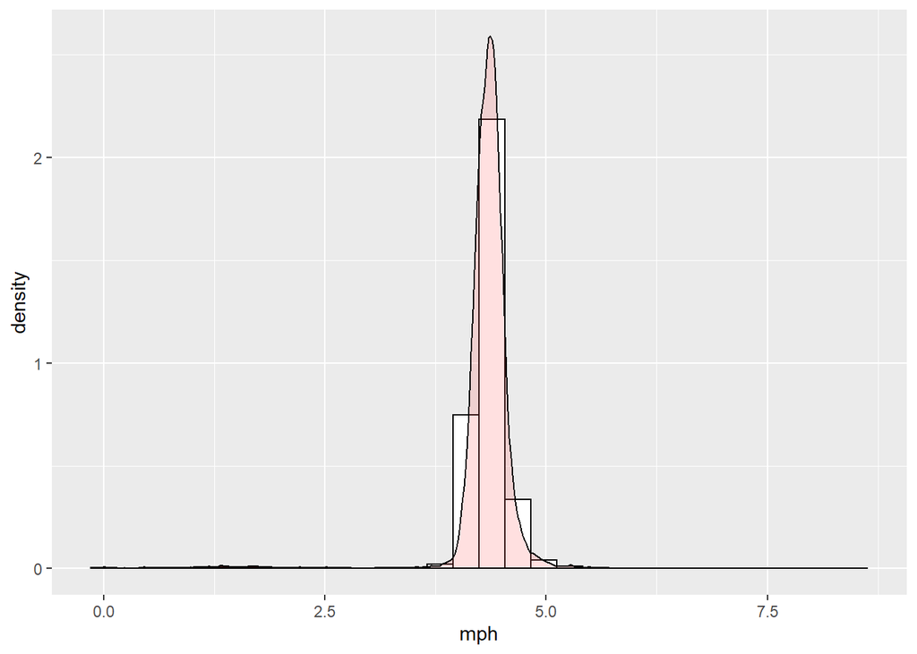

[output not shown]

```
Now lets quickly find the fastest bikes by avg mph and compare how far each has traveled
```

```r
ggplot(bikeiddata, aes(x=mph)) + geom_histogram(aes(y=..density..), colour="black", fill="white") + geom_density(alpha=.2, fill="#FF6666")
```

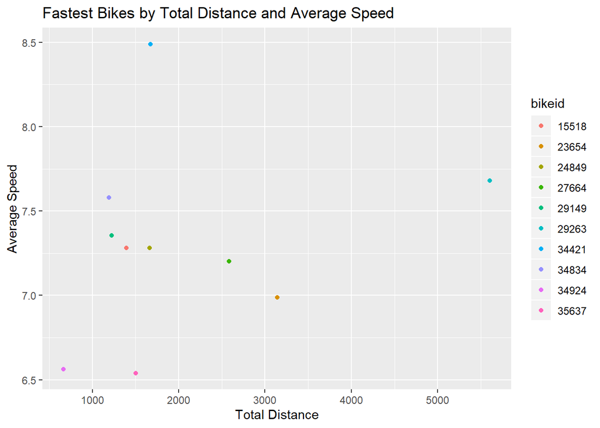

```r
#Avg Speed of Fastest Bikes
fastestbikes <- bikeiddata[order(-bikeiddata$mph),]
fastestbikes<- head(fastestbikes, 10)
baseplot <- ggplot(data=fastestbikes, aes(x=totaltripdist, y=mph, color=bikeid))
baseplot + geom_jitter() + ggtitle("Fastest Bikes by Total Distance and Average Speed") +
  xlab("Total Distance") + ylab("Average Speed")
```

### All Used Station Combos

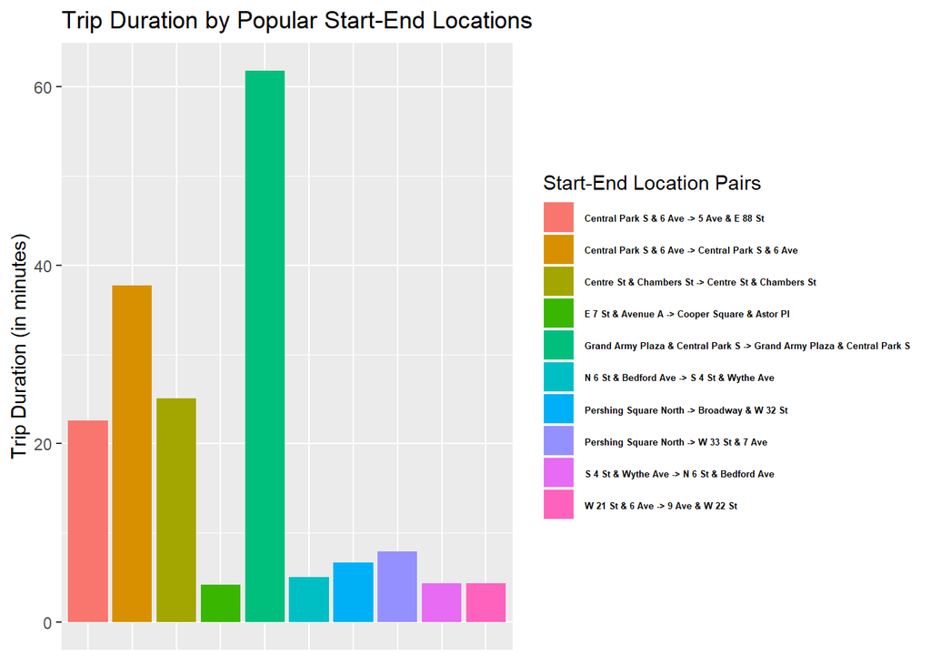

[output not shown]

```r
results <- test %>%
  group_by(start.station.name, end.station.name) %>%
  select(start.station.name, end.station.name, tripDurationMin) %>%
  summarise(avgTrip = median(tripDurationMin, na.rm = TRUE), count= n()) %>%
  distinct()


results <- results[order(-results$count),]
results <- head(results, 10)


results$combined <- paste(results$start.station.name, "->", results$end.station.name)
p <- ggplot(results, aes(x = combined, y = avgTrip, fill = combined)) + geom_bar(stat = "identity")  + ggtitle("Trip Duration by Popular Start-End Locations")+ theme(axis.title.x=element_blank(),
        axis.text.x=element_blank(),
        axis.ticks.x=element_blank()) + labs(y= "Trip Duration (in minutes)" ,fill = "Start-End Location Pairs")

p + theme(legend.text = element_text(colour="black", size=5,
                                     face="bold"))
```

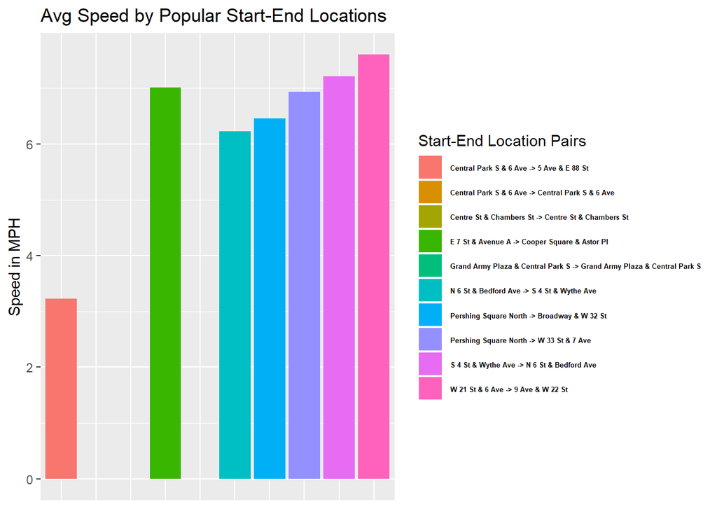

```
Here we see that the averaege speed for the most popular loactinos is just over 6 MPH with only one location with data coming in below 6.

NOTE: Some of these bars don't show up because there is no speed data for them, even though they are a very popular route. This is becasue their start and end locations are generally the exact same, if not always.
```

```r
results <- test %>%
  group_by(start.station.name, end.station.name) %>%
  select(start.station.name, end.station.name, mph) %>%
  summarise(avgTrip = median(mph, na.rm = TRUE), count= n()) %>%
  distinct()


results <- results[order(-results$count),]
results <- head(results, 10)


results$combined <- paste(results$start.station.name, "->", results$end.station.name)
p <- ggplot(results, aes(x = combined, y = avgTrip, fill = combined)) + geom_bar(stat = "identity")  + ggtitle("Avg Speed by Popular Start-End Locations")+ theme(axis.title.x=element_blank(),
        axis.text.x=element_blank(),
        axis.ticks.x=element_blank()) + labs(y= "Speed in MPH" ,fill = "Start-End Location Pairs")

p + theme(legend.text = element_text(colour="black", size=5,
                                     face="bold"))
```

# Question 2: Identify patterns in the ride history data

Explain/illustrate these patterns using appropriate visualization. This is purposely open ended. You are expected to pose interesting questions and answer them (e.g. does the ridership pattern differ between weekdays and weekends?)

## Data Manipulation

```r
#Creating column for weekday and time in day
test$weekday <- wday(test$starttime)
test$timeInDay <- ifelse(hour(test$starttime) >= 4 & hour(test$starttime) < 12, "morning", ifelse(hour(test$starttime) >= 12 & hour(test$starttime) < 16, "afternoon",ifelse(hour(test$starttime) >= 16 & hour(test$starttime) < 20, "evening", "night")))
```

## Daily Trend

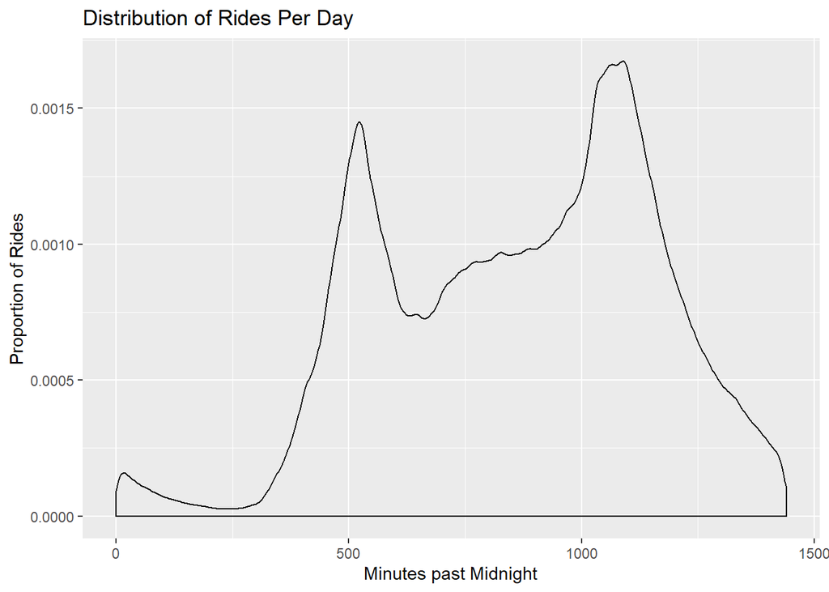

[output not shown]

```r
# The y axis represents the proportion of rides at each point along the day
ggplot(test, aes(x=pastTime)) + geom_density() + labs(x="Minutes past Midnight", y = "Proportion of Rides") + ggtitle("Distribution of Rides Per Day")
```

## Day Trend

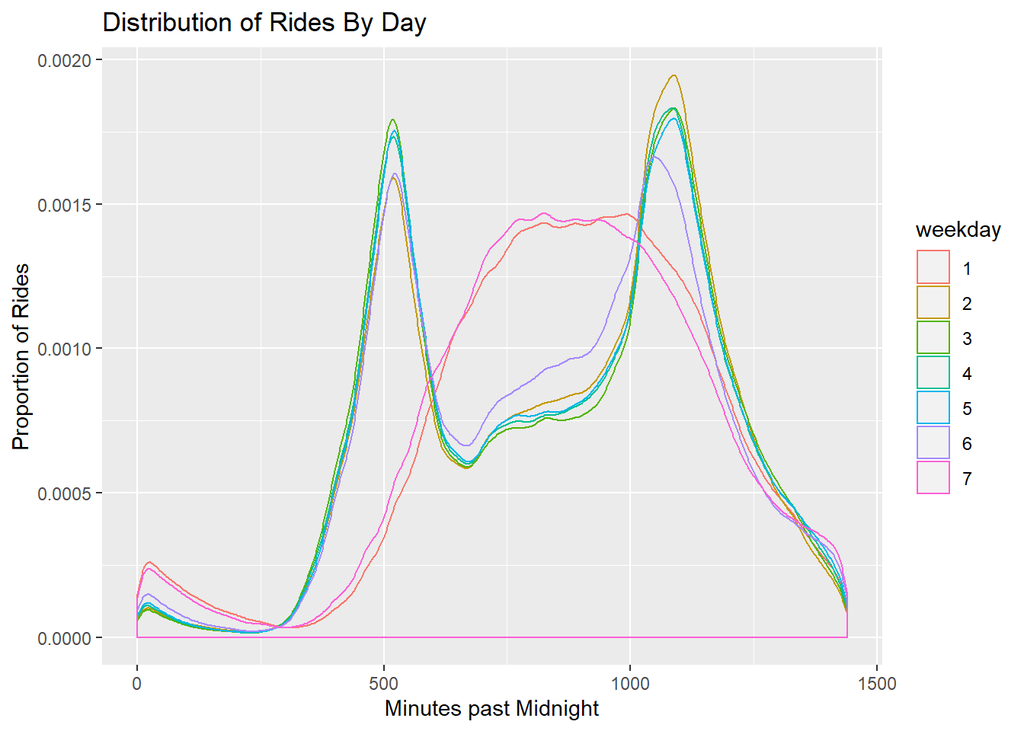

[output not shown]

```r
test$weekday <-as.character(test$weekday) #from 1 for Sunday to 7 for Saturday
ggplot(test, aes(x=pastTime, colour = weekday)) + geom_density() + labs(x="Minutes past Midnight", y = "Proportion of Rides") + ggtitle("Distribution of Rides By Day")
```

## Day Type Trend

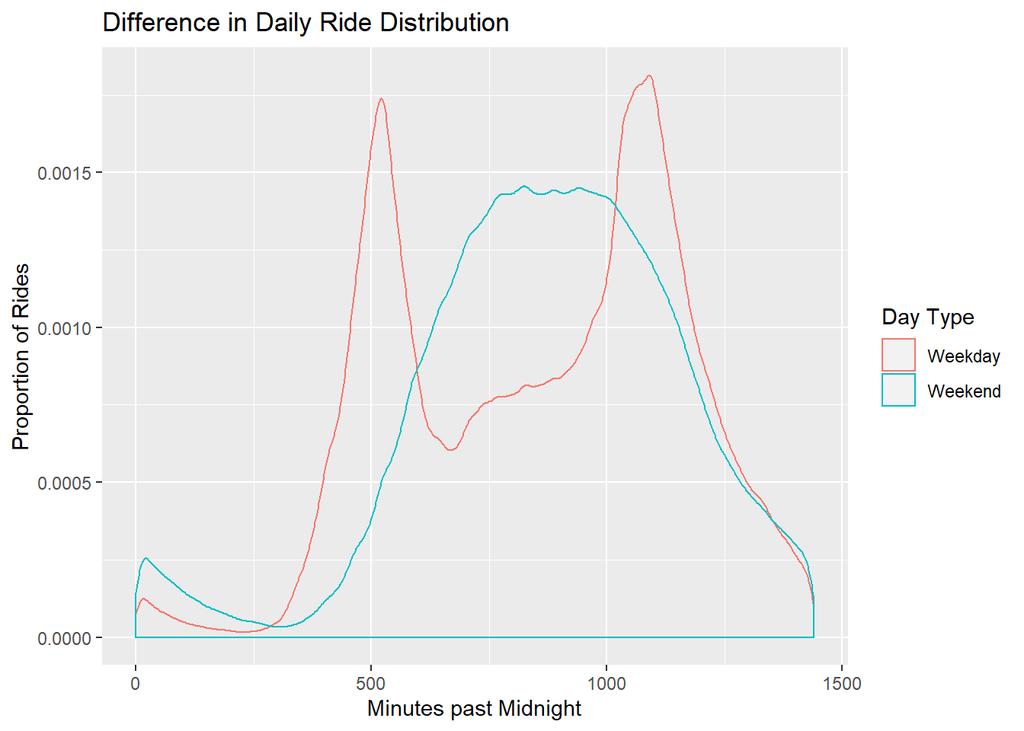

[output not shown]

```r
test <- test %>%
  mutate(dayType = ifelse(weekday==1 | weekday == 7, "Weekend", "Weekday"))

ggplot(test, aes(x=pastTime, colour = dayType)) + geom_density() + labs(x="Minutes past Midnight", colour = "Day Type", y = "Proportion of Rides", title = "Difference in Daily Ride Distribution")
```

## Generation Trends

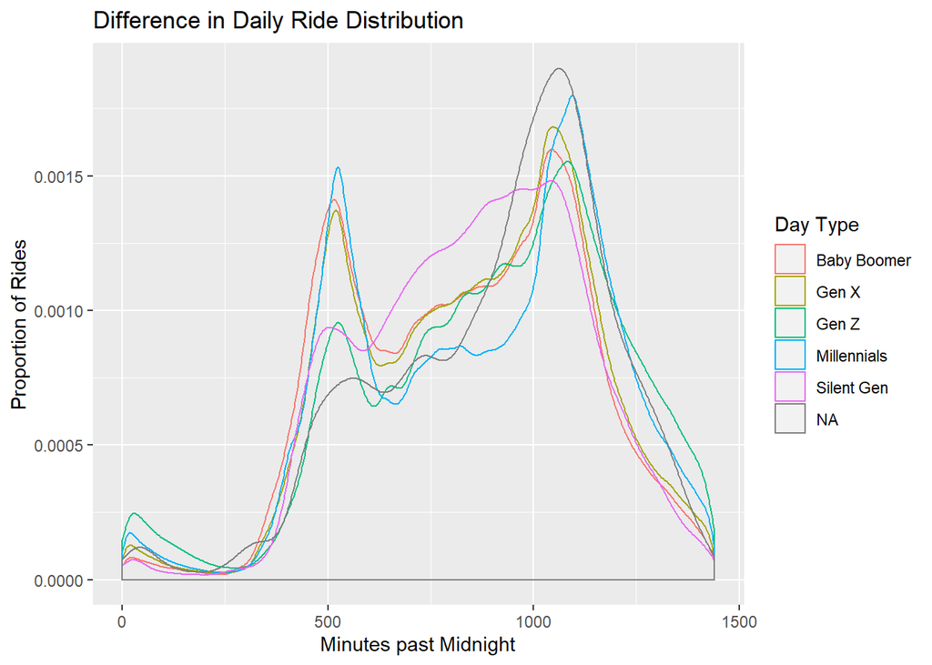

[output not shown]

```r
ggplot(test, aes(x=pastTime, colour = generation)) + geom_density() + labs(x="Minutes past Midnight", colour = "Day Type", y = "Proportion of Rides", title = "Difference in Daily Ride Distribution")
```

## Gender Trends

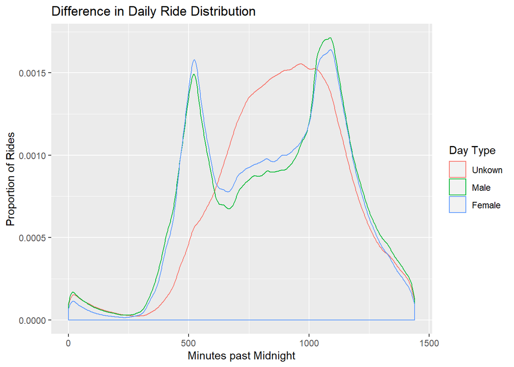

[output not shown]

```r
ggplot(test, aes(x=pastTime, colour = gender)) + geom_density() + labs(x="Minutes past Midnight", colour = "Day Type", y = "Proportion of Rides", title = "Difference in Daily Ride Distribution")
```

# Question 3: Assymetric Traffic

Stations running out of bikes because of assymetric traffic (arrivals and departures are not equal, either arrival >> departure or departure >> arrival) is a big problem. Client would want to know which stations are candidates for increasing bike storage capacity. Client would like to see these stations on a map based visualization.

## Notes

[output not shown]

## Data

### Getting Stations and Flows

```r
# Get a stations outDegree
stationGroup_temp <- test %>%
  group_by(end.station.name) %>%
  summarise(inDegree=n()) %>%
  rename(stationName = end.station.name)

# Get a stations inDegree
stationGroup <- test %>%
  group_by(start.station.name, start.station.latitude, start.station.longitude) %>%
  summarise(outDegree=n()) %>%
  rename(stationName = start.station.name)

# Join the frames and removes the old one
stationGroup <- full_join(stationGroup_temp, stationGroup, by="stationName")
remove(stationGroup_temp)

# Replace with NA those stations that do not have a name
stationGroup[stationGroup == "NULL"] <- NA

# Gets rid of all the rows with NA
stationGroup <- stationGroup[complete.cases(stationGroup[,1:3]),]

# Calculates overFlow and makes a messeage
stationGroup <- stationGroup %>%
  mutate(overFlow=inDegree - outDegree)
stationGroup <- stationGroup %>%
  mutate(message = paste(stationName, paste("Overflow: ", overFlow), sep='\n'))
```

## Map

### Icon Import

```r
#Changing map markers to bikes
station <- data.frame(distinct(test,start.station.name, start.station.latitude, start.station.longitude))

# Replace with NA those stations that do not have a name
station[station == "NULL"] <- NA

# Gets rid of all the rows with NA
station <- station[complete.cases(station[,1:3]),]

testMap <- leaflet() %>%
  addTiles() %>%
  addMarkers(lat = station$start.station.latitude, lng = station$start.station.longitude, popup = station$stationName, clusterOptions = markerClusterOptions())

testMap
```

[interactive chart not shown]

### Finding Outliers

```r
getColor <- function(hm) {
  sapply(hm$overFlow, function(overFlow) {
  if(overFlow <= quantile(stationGroup$overFlow, .95, na.rm = TRUE) &
     overFlow >= quantile(stationGroup$overFlow, .05, na.rm = TRUE)) {
    "green"
  } else if(overFlow >= quantile(stationGroup$overFlow, .99, na.rm = TRUE) |
            overFlow <= quantile(stationGroup$overFlow, .01, na.rm = TRUE)) {
    "red"
  } else {
    "orange"
  } })
}

icons <- awesomeIcons(
  icon = 'ios-close',
  iconColor = 'black',
  library = 'ion',
  markerColor = getColor(stationGroup)
)
```

### Map Placement

```r
# station <- data.frame(distinct(test,start.station.name, start.station.latitude, start.station.longitude))
testMap <- leaflet() %>%
  addTiles() %>%
  addAwesomeMarkers(lat = stationGroup$start.station.latitude, lng = stationGroup$start.station.longitude, popup = stationGroup$message, clusterOptions = markerClusterOptions(), icon=icons)

testMap
```

[interactive chart not shown]

[output not shown]

## Summary

### Worst Stations

```r
top10Worst <- stationGroup %>%
  arrange(desc(overFlow)) %>%
  slice(1:10) %>%
  select(stationName, overFlow)

bot10Worst <- stationGroup %>%
  arrange(overFlow) %>%
  slice(1:10) %>%
  select(stationName, overFlow)
```

```
Stations that get the most Overflow:
```

```r
top10Worst %>%
  select(Station = stationName,
         `Over Flow`=overFlow) %>%
  kable() %>%
  kable_styling(c("striped", "hover", "condensed"), full_width = F)
```

| Station | Over Flow |
| --- | --- |
| 11 Ave & W 59 St | 42627 |
| E 13 St & Avenue A | 37885 |
| DeKalb Ave & Hudson Ave | 11942 |
| E 13 St & Avenue A | 10038 |
| E 10 St & Avenue A | 7296 |
| Old Fulton St | 6991 |
| Broadway & Battery Pl | 6650 |
| West St & Chambers St | 4957 |
| E 2 St & Avenue B | 4542 |
| E 17 St & Broadway | 4453 |

```
Stations that got used the most:
```

```r
bot10Worst %>%
  select(Station = stationName,
         `Over Usage`=overFlow) %>%
  kable() %>%
  kable_styling(c("striped", "hover", "condensed"), full_width = F)
```

| Station | Over Usage |
| --- | --- |
| Columbus Ave & W 72 St | -17197 |
| Grand Army Plaza & Central Park S | -10093 |
| W 76 St & Columbus Ave | -6992 |
| Clark St & Henry St | -6809 |
| W 89 St & Columbus Ave | -6214 |
| Lafayette Ave & St James Pl | -5640 |
| W 82 St & Central Park West | -5581 |
| Bialystoker Pl & Delancey St | -5463 |
| E 7 St & Avenue A | -5297 |
| Central Park W & W 96 St | -5173 |

[output not shown]

# Question 4: Impact of Weather

Client wants to know the impact of weather (temperature, rain, snow, wind) on the CitiBike system. You are asked to find an appropriate data source for 2018 weather data and use it for your analysis.

## Data Manipulation

### Adding Weather Data

```r
weatherData <- read.csv("Weather_NYC_2018.csv")
```

```r
#Merging two data set
test$date <- as.Date(test$starttime)
weatherData <- weatherData %>%
      mutate(DATE = mdy(DATE)) %>%
      rename(date = DATE)

weatherData$TAVG <- (weatherData$TMIN+weatherData$TMAX)/2

dailySummary <- test %>%
  group_by(date) %>%
  summarise(
    avgDistance = mean(dist, na.rm = TRUE),
    avgDuration = mean(tripDurationMin, na.rm = TRUE),
    avgSpeed = mean(mph, na.rm=TRUE)
  )

mergeTest1 <- merge(dailySummary, weatherData, by="date")
```

```r
mergeTest <- merge(test[, c("pastTime", "generation", "usertype", "gender", "date")], weatherData[ , c("date", "AWND", "TAVG", "SNOW", "PRCP")], by="date")
```

## Data Analysis

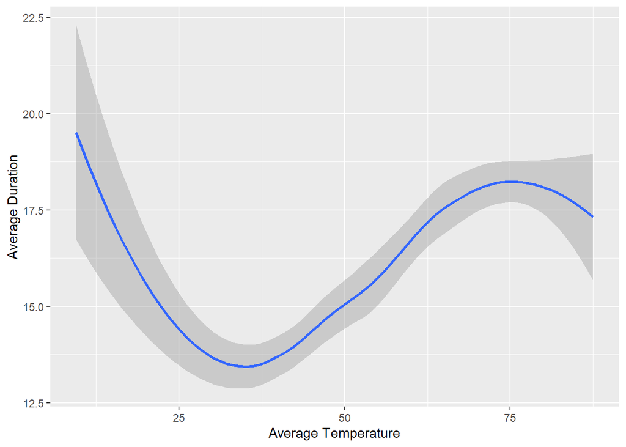

```
While it may be interesting to see, it seems that temperature does not have too much of an obvious effect on duration. When it is very cold trips actually take the longest time on avereage.
```

```r
ggplot(mergeTest1, aes(x=TAVG, y=avgDuration)) + geom_smooth() + labs(x= "Average Temperature", y="Average Duration")
```

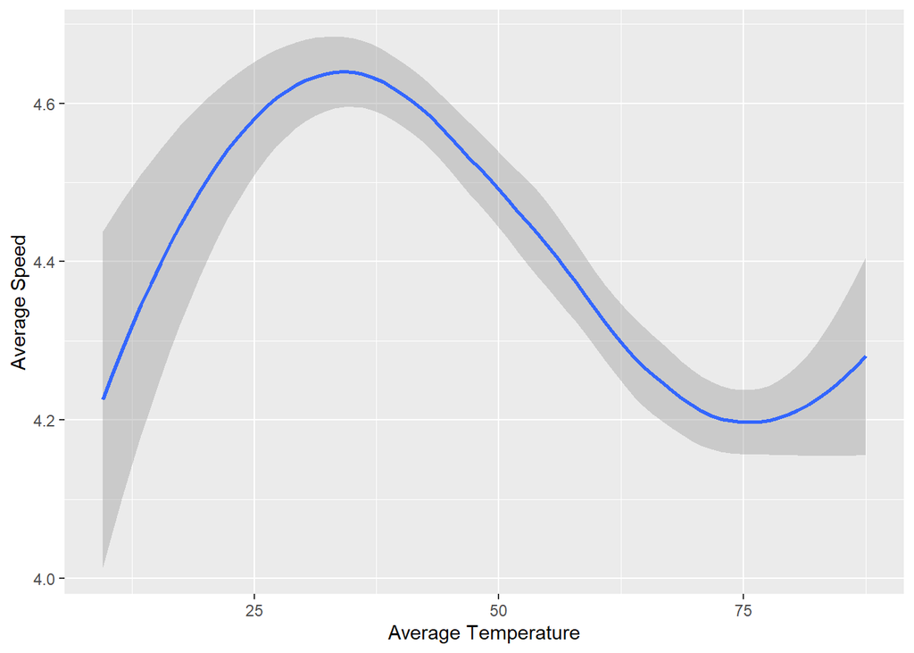

```r
ggplot(mergeTest1, aes(x=TAVG, y=avgSpeed)) + geom_smooth() +  labs(x= "Average Temperature", y="Average Speed")
```

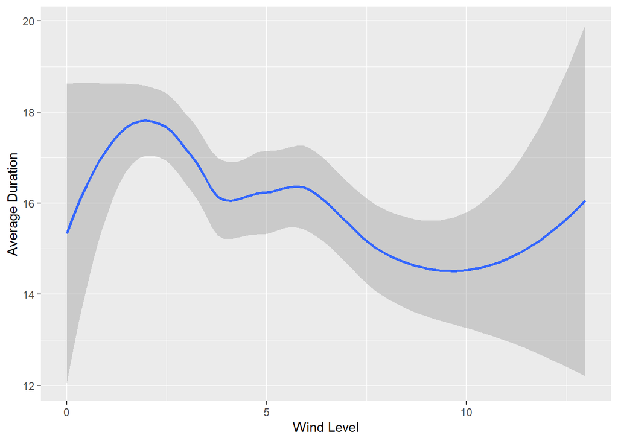

[output not shown]

```r
ggplot(mergeTest1, aes(x=AWND, y=avgDuration)) + geom_smooth() + labs(x= "Wind Level", y="Average Duration")
```

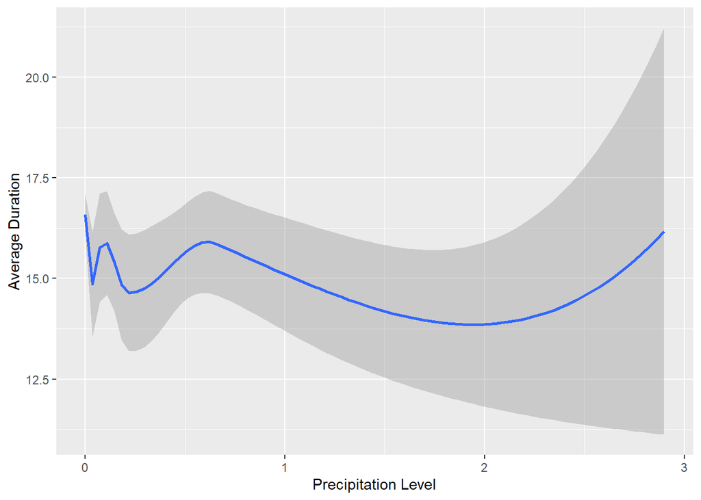

```r
ggplot(mergeTest1, aes(x=PRCP, y=avgDuration)) + geom_smooth() + labs(x= "Precipitation Level", y="Average Duration")
```

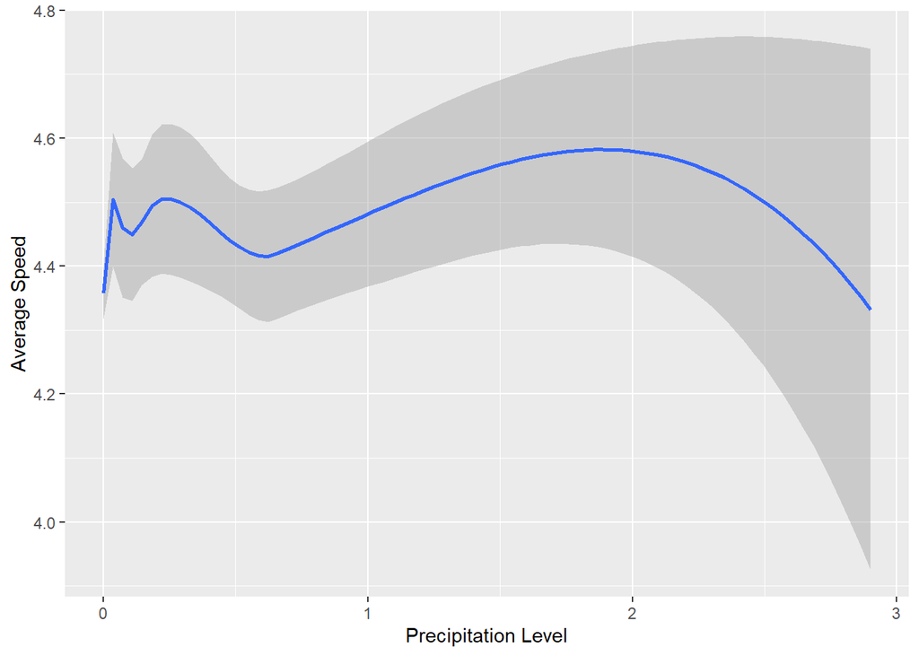

```r
ggplot(mergeTest1, aes(x=PRCP, y=avgSpeed)) + geom_smooth() + labs(x= "Precipitation Level", y="Average Speed")
```

# Question 5: Extra Analysis

## Holiday Effect

### Importing Holidays

```r
holidays <- read.csv("holidays.csv", header=FALSE)
```

### Building Data Set

```r
holidays <- holidays %>%
  mutate(V1 = mdy(V1)) %>%
  rename(date = V1)

test <- test %>%
  mutate(holiday = ifelse(date %in% holidays$date, TRUE, FALSE))
```

### Ploting

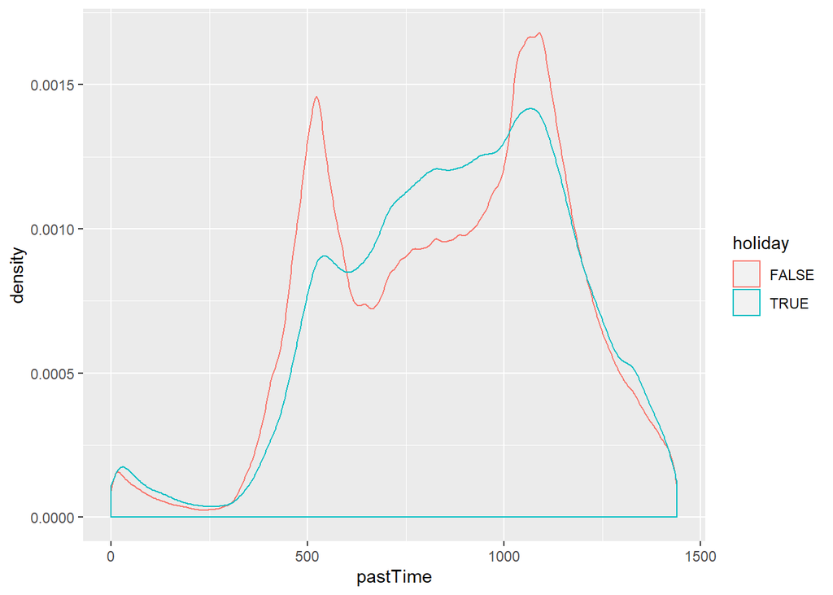

[output not shown]

```r
ggplot(test, aes(x=pastTime, colour=holiday)) + geom_density()
```